# Analiza danych - projekt

Paweł Cyrocki; Damian Skinder; Patryk Siuda

2026-01-31

# 1.Wstęp

Niniejszy dokument opisuje projekt zespołowy dotyczący analizy danych przy użycia języka R. Projekt obejmuje zbieranie, przetwarzanie, analizę oraz wizualizację danych. Jego celem jest porównawcza analiza cenowa i predykcja wartości samochodów premium na polskim rynku wtórnym.

Dane do analizy pozyskano ze strony: https://www.kaggle.com/datasets/bartoszpieniak/poland-cars-for-sale-dataset.

## 1.1 Założenia projektu

Analizę ograniczono do samochodów marek BMW i Mercedes-Benz, co wynika z konieczności zapewnienia wysokiej jakości statystycznej danych. Szeroki zakres wszystkich marek (~200k obserwacji, 20+ brandów) wprowadza znaczną heteroskedastyczność (różną wariancję reszt w modelach regresji) oraz nadmiar obserwacji odstających, co destabilizuje estymatory i obniża moc testów hipotez. Aby analizowane wartosci były bardziej miarodajne do badania posłużyły ogłoszenia dla samochodów używanych.

## 1.2 Opis zmiennych

`Index` - unikalny identyfikator ogłoszenia

`Price` - cena samochodu

`Currency` - waluta, w której podana jest cena

`Condition` - stan samochodu (nowy/używany)

`Vehicle_brand` - marka samochodu

`Vehicle_model` - model samochodu

`Vehicle_version` - wersja samochodu

`Vehicle__generation` - generacja samochodu

`Production_year` - rok produkcji samochodu

`Mileage__km` - przebieg samochodu w kilometrach

`Power_HP` - moc samochodu w koniach mechanicznych

`Displacement__cm3` - pojemność silnika w centymetrach sześciennych

`Fuel_type` - rodzaj paliwa

`CO2_emission` - emisja CO2 w gramach na kilometr

`Drive` - typ napędu

`Transmission` - rodzaj skrzyni biegów

`Type` - typ nadwozia

`Doors_nuber1` - liczba drzwi

`Colour` - kolor samochodu

`Orgin_country` - kraj pochodzenia

`First_owner` - czy właściciel jest pierwszym właścicielem

`First_registration_date` - data pierwszej rejestracji

`Offer_publication_date` - data publikacji ogłoszenia

`Offer_location` - lokalizacja oferty

`Features` - cechy dodatkowe samochodu

## 1.3 Hipotezy badawcze

W tej części definiujemy hipotezy, które będą weryfikowane w dalszej analizie eksploracyjnej oraz modelowaniu.

**H1 (Cena a przebieg)**  
Samochody BMW i Mercedes z większym przebiegiem mają istotnie niższą cenę niż z mniejszym przebiegiem, z potencjalnie silniejszą zależnością u Mercedes. Weryfikacja: analiza zależności między zmiennymi `Price` i `Mileage_km` (wykresy rozrzutu, korelacja, model regresji).

**H2 (Cena a rok produkcji)**  
Nowsze modele BMW i Mercedes są droższe niż starsze, przy czym BMW może szybciej tracić na wartości w porównaniu do Mercedes. Weryfikacja: analiza związku `Price` z `Production_year` (przedziały roczników, wykresy pudełkowe, modele regresji).

**H3 (Typ nadwozia a cena)**  
W segmencie BMW i Mercedes SUV-y/crossovery są droższe niż sedany/hatchbacki, z różnicami między markami (np. większe premiowanie SUV-ów u BMW). Weryfikacja: porównanie rozkładów `Price`między kategoriami zmiennej `Type` (boxploty, testy różnic średnich / ANOVA).

**H4 (Skrzynia biegów a cena)**  
Samochody BMW i Mercedes z automatyczną skrzynią biegów są średnio droższe niż samochody z manualną skrzynią biegów (mocniej dla Mercedesa) Weryfikacja: porównanie cen w dwóch grupach (`Transmission` = automat vs manual) z użyciem odpowiednich testów statystycznych i wizualizacji - proponowane wykorzystanie t-test lub Wilcoxon Price ~ Transmission w podzbiorach marek, wizualizacja violin plots.

**H5 (Pierwszy właściciel a cena)**  
BMW i Mercedes od pierwszego właściciela są droższe, z większą premią u Mercedes ze względu na prestiż. Weryfikacja: porównanie cen dla zmiennej `First_owner` (tak vs nie) z wykorzystaniem wykresów oraz testów różnic średnich.

**H6 (Napęd a cena)**  
Samochody BMW i Mercedes z napędem na cztery koła (4x4) są średnio droższe niż samochody z napędem na jedną oś, przy porównywalnych pozostałych parametrach, szczególnie w modelach BMW. Weryfikacja: porównanie rozkładów ceny pomiędzy kategoriami zmiennej `Drive` (np. FWD, RWD, 4x4) z uwzględnieniem innych cech w modelu (m.in. `Power_HP`, `Production_year`), np. regresja `Price` ~ `Drive` * `Vehicle_brand` + `Power_HP` + `Production_year`

**H7 (Moc silnika a cena)**  
Wyższa moc (Power_HP) koreluje z ceną w obu markach po kontroli przebiegu i roku, z silniejszą relacją u BMW sportowych modeli. Weryfikacja: model regresji z ceną jako zmienną zależną i `Power_HP`, `Mileage_km`, `Production_year` jako głównymi zmiennymi objaśniającymi.

**H8 (Paliwo a cena – BMW vs Mercedes)** Hybrydy i elektryki BMW/Mercedes są droższe niż diesle/benzyna przy porównywalnym przebiegu i roku, z większą premią u Mercedes (ekoprestiż). Weryfikacja: boxplot `Price` ~ `Fuel_type` * `Vehicle_brand`, regresja z kontrolą `Mileage_km` + `Production_year`.

**H9 (Kolor a cena – premium psychologia)** Popularne kolory kojarzone z markami premium (czarny, szary, biały) osiągają wyższe ceny niż mniej typowe (czerwony, zielony), mocniej u Mercedes. Weryfikacja: violin plot `Price` ~ `Coluor` * `Vehicle_brand`, ANOVA z TukeyHSD post-hoc.

**H10 (Trwałość marki – cena/km)** Mercedes ma wyższy stosunek `Price`/`Mileage_km` niż BMW (lepsza wartość rezydualna) dla aut >10 lat. Weryfikacja: cena_per_km <- `Price` / `Mileage_km`, boxplot po grupach `Production_year` + marka, t-test.

**H11 (Cena a moc i lokalizacja – BMW vs Mercedes (województwa))** Średnia moc silnika `Power_HP` BMW i Mercedesa jest wyższa w regionach o wyższej średniej cenie `Price` ofert.

# 2. Porządkowanie danych

W tym rozdziale opisano proces porządkowania danych, w tym obsługę braków danych, transformacje zmiennych oraz usuwanie obserwacji odstających. Podjęte zdiałania mają na celu przygotowanie danych do dalszej analizy opisowej i testowania statystycznego.

## 2.1 Braki danych

Pierszym krokiem będzie identyfikacja zmiennych, które zawierają braki. Za pomocą funkcji `aggr` z pakietu `VIM` utworzono wykres pokazujący braki danych w poszczególnych zmiennych.

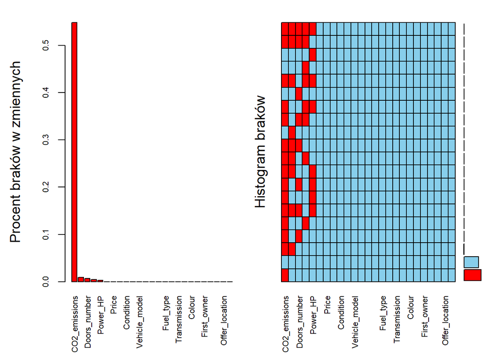

Wykres pokazuje bardzo duże braki w zmiennej `CO2_emissions`, która nie jest parametrem kluczowym dla naszych analiz, dlatego zostanie usunięta z dalszej analizy. Pozostałe zmienne z brakami danych będą poddane dalszej analizie w celu określenia, czy braki są losowe, czy systematyczne.

Następnie, za pomocą funkcji `geom_miss_point` z pakietu `naniar`, wizualizujemy braki danych w dwóch kluczowych zmiennych: `Displacement_cm3` i `Power_HP`. Pozwoli to ocenić, czy braki w tych zmiennych są powiązane ze sobą lub z innymi cechami danych.

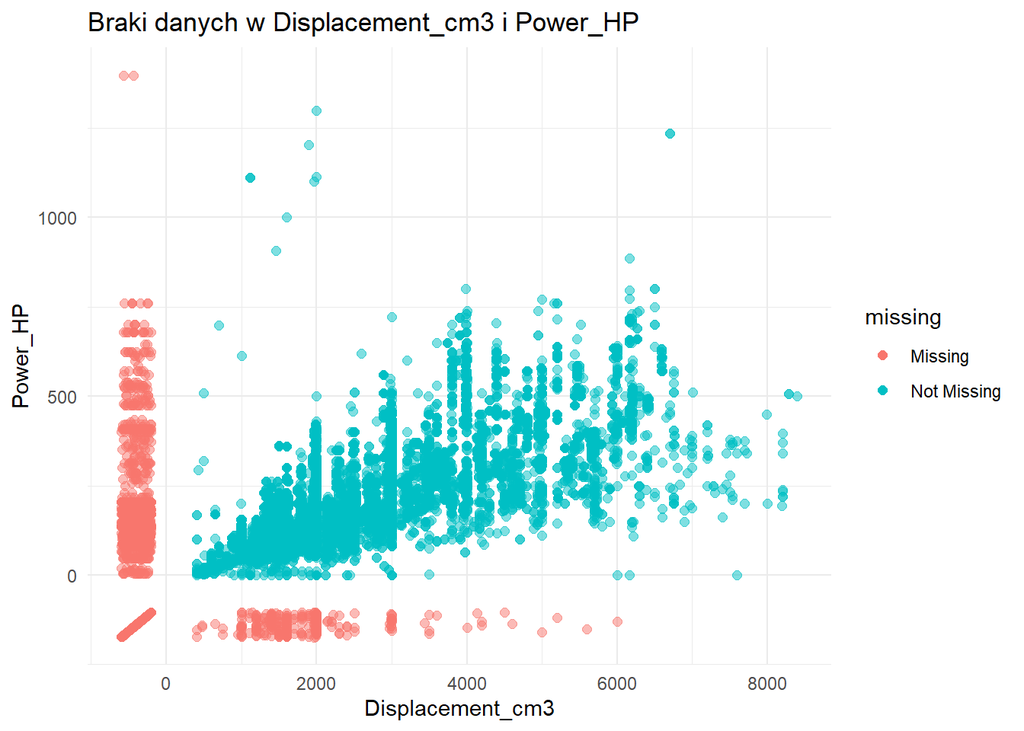

Na podstawie wykresu możemy zauważyć występowanie liniowej zależności między zmiennymi `Displacement_cm3` i `Power_HP`, dlatego braki w danych zostały uzupełnione za pomocą metody `mice`. Po wykonanej implementacji danych sprawdzamy za pomocą takiego samego wykresu, czy wszystkie braki dla wymienionych zmiennych zostały wyeliminowane.

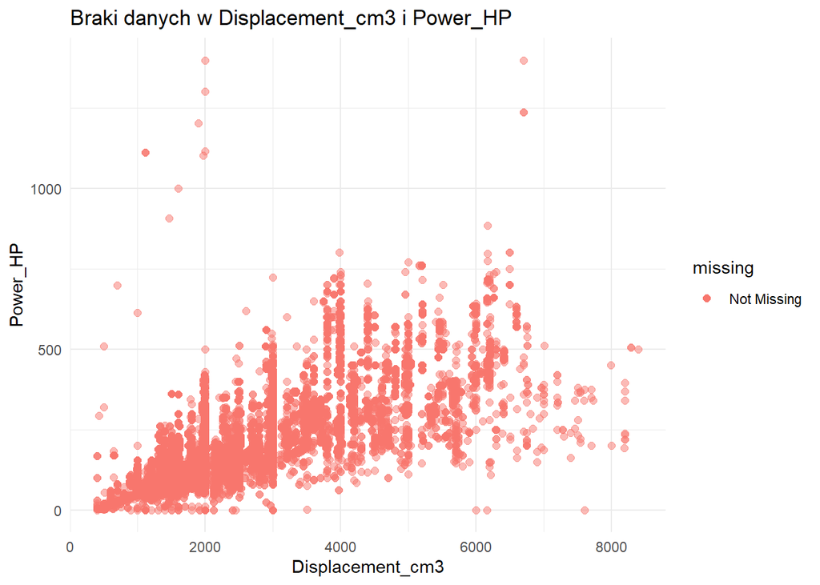

Dla pozostałych zmiennych, wktórych występowały braki danych również zastosowano metodę `mice`, zmienna `Mileage` została wyestymowana za pomocą zależności od zmiennych: `Production_yea` oraz `Power_HP`, natomiast zmienna `Doors_number` na podstawie zmiennej `Type`.

Na koniec sprawdzono czy wszystkie braki danych zostały usunięte.

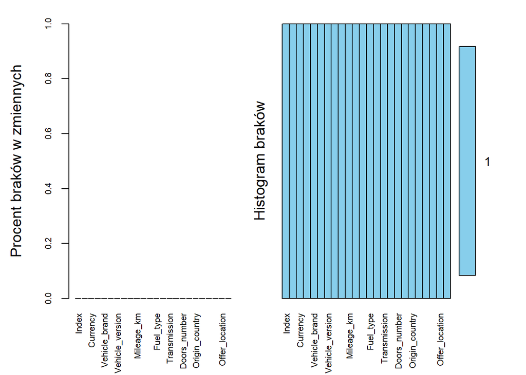

## 2.2 Walidacja danych

W celu eliminacji obserwacji odstających, które mogą zniekształcić wyniki analizy, przeprowadzono walidację danych dla kluczowych zmiennych. Poniżej przedstawiono przyjęte kryteria walidacji:

`Price` - powinna być większa od 0.

`Mileage_km` - musi być liczbą nieujemną i mniejsze od 999999 km.

`Production_year` - musi być liczbą całkowitą mieszczącą się w rozsądnym zakresie od 1886 do 2025r.

`Power_HP` - musi być liczbą większą niż 1.

`Displacement_cm3` - musi być liczbą większą niż 1.

`Doors_number` - musi być liczbą całkowitą z przedziału 1-6.

Poniższa tabela przedstawia liczebności obserwacji spełniających oraz niespełnijących powyższe kryteria:

(#tab:unnamed-chunk-10)Podsumowanie reguł walidacyjnych danych

| Reguła | Łącznie | Spełnione | Niespełnione |
| --- | --- | --- | --- |
| V1 | 208304 | 208304 | 0 |
| V2 | 208304 | 208304 | 0 |
| V3 | 208304 | 208304 | 0 |
| V4 | 208304 | 208260 | 44 |
| V5 | 208304 | 208251 | 53 |
| V6 | 208304 | 208304 | 0 |
| V7 | 208304 | 208291 | 13 |

Zmienne niespełniające kryteria walidacji zostały oznaczone jako braki danych (NA). Natępnie przeprowadzono kolejną walidację dla nowych braków zmiennych analogicznie jak w kroku 2.1.

Po walidacji sprawdzono czy wszystkie braki danych zostały usunięte.

Finalna procentowa zawartość danych bez braków: 100 %

Ostatecznie mamy dane, które spełniają kryteria walidacji i nie zawierają braków danych. Możemy przejść do dalszej analizy danych. Dla uzyskanych danych wybieramy marki Mercedes i BMW do dalszej analizy.

# 3. Weryfikacja hipotez, wizualizacja, analiza opisowa oraz testy statystyczne

## 3.1 Główna statystyka opisowa

Poniżej przedstawiono główne statystyki opisowe dla zmiennych numerycznych w zbiorze danych. Statystyki dotyczą używanych samochodów marek BMW oraz Mercedes Benz. Poniżej przedstawiono tabelę zawierającą liczebność próby, średnie wartości kluczonych zmiennych.

(#tab:opisowa-tabela)Statystyki opisowe dla cen w PLN – BMW vs Mercedes-Benz

| Marka | Liczba ogłoszeń | Średnia | SD | Min | Q1 | Mediana | Q3 | Max |
| --- | --- | --- | --- | --- | --- | --- | --- | --- |
| BMW | 15150 | 78 568 | 100 574 | 1 300 | 24 500 | 51 900 | 99 000 | 6 999 000 |
| Mercedes-Benz | 10928 | 91 710 | 111 847 | 1 000 | 22 500 | 52 500 | 120 824 | 1 398 999 |

## 3.2 Weryfikacja hipotez

### 3.2.1 Hipoteza H1 (`Cena a przebieg`)

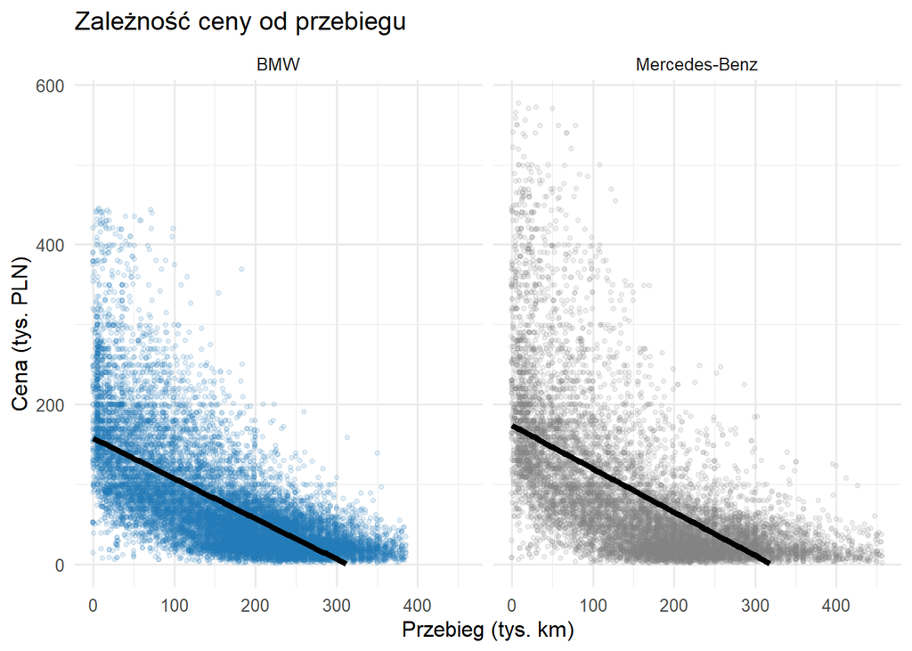

Wyniki dla aut używanych (po odcięciu górnego 1% wartości `Price` i `Mileage_km` w obrębie każdej marki) wspierają hipotezę H1: wraz ze wzrostem przebiegu cena spada, co widać po wyraźnie opadającej linii trendu w obu panelach (BMW i Mercedes-Benz). Zależność tę potwierdza także `współczynnik korelacji Pearsona` między przebiegiem a ceną, który jest ujemny dla obu marek (BMW: r ≈ `−0.67`, Mercedes-Benz: r ≈ `−0.61`), co oznacza, że większy przebieg wiąże się przeciętnie z niższą ceną (nieco silniej w BMW).

Z tabeli wynika, że „typowe” ceny są bardzo zbliżone (`mediany ok. 52 tys. PLN dla obu marek`), ale `Mercedes ma wyżej położoną górną część rozkładu cen` (Q3 wyższe niż w BMW), co widać też w większej liczbie droższych punktów przy mniejszych przebiegach.

Na wykresie `widać również skośność cen`: większość obserwacji skupia się przy niższych poziomach cen, a jednocześnie występuje „ogon” droższych ofert (zwłaszcza przy niskich przebiegach), co jest typowym obrazem prawostronnie skośnego rozkładu cen i tłumaczy, dlaczego średnia bywa wyższa od mediany.

### 3.2.2 Hipoteza H2 (`Cena a rok produkcji`)

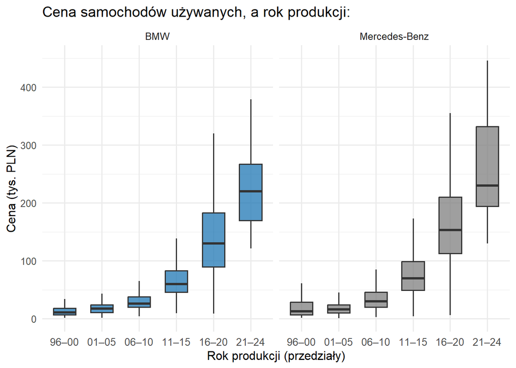

(#tab:unnamed-chunk-21)Cena samochodów W PLN według roku produkcji

| Marka | Rok grupy | Liczba | Średnia | Q1 | Mediana | Q3 |
| --- | --- | --- | --- | --- | --- | --- |
| BMW | 96–00 | 393 | 16 253 | 6 990 | 11 500 | 20 000 |
| BMW | 01–05 | 1 433 | 17 680 | 8 900 | 13 900 | 22 500 |
| BMW | 06–10 | 3 825 | 28 043 | 18 500 | 23 800 | 30 900 |
| BMW | 11–15 | 4 120 | 60 804 | 39 969 | 53 900 | 71 999 |
| BMW | 16–20 | 4 391 | 128 356 | 79 900 | 109 900 | 163 590 |
| BMW | 21–24 | 670 | 216 332 | 159 900 | 199 900 | 259 900 |
| Mercedes-Benz | 96–00 | 380 | 29 587 | 7 952 | 16 000 | 42 600 |
| Mercedes-Benz | 01–05 | 1 347 | 21 395 | 8 900 | 14 900 | 22 200 |
| Mercedes-Benz | 06–10 | 2 597 | 34 157 | 16 900 | 26 900 | 39 900 |
| Mercedes-Benz | 11–15 | 2 236 | 71 883 | 42 000 | 57 350 | 84 900 |
| Mercedes-Benz | 16–20 | 2 839 | 153 661 | 93 900 | 135 000 | 186 050 |
| Mercedes-Benz | 21–24 | 516 | 226 295 | 160 490 | 199 900 | 279 900 |

Dla aut używanych (BMW i Mercedes-Benz) porównano `ceny w przedziałach rocznika produkcji`, a do analizy przyjęto ten sam zakres co na wykresie (ceny ograniczone do 450000 PLN).

Boxploty potwierdzają te obserwacje wizualnie: mediany w kolejnych grupach rocznika układają się „schodkowo” coraz wyżej, a `rozrzut jest większy w nowszych przedziałach` (16–20 i 21–24), co sugeruje `większą różnorodność cen w nowszych autach` (różne wersje/wyposażenia).

### 3.2.3 Hipoteza H3 (`Typ nadwozia a cena`)

Weryfikacja: porównanie rozkładów `Price`między kategoriami zmiennej `Type`

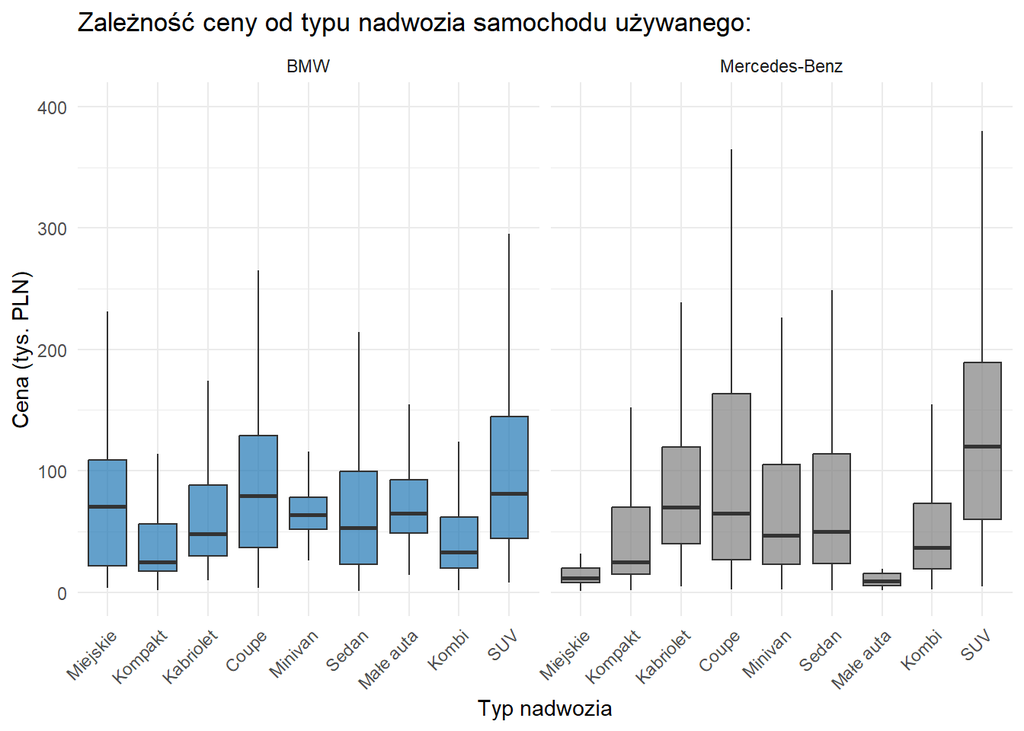

(#tab:unnamed-chunk-23)Cena w PLN według typów nadwozia BMW vs Mercedes-Benz

| Marka | Typ nadwozia | Liczba | Średnia | Q1 | Mediana | Q3 |
| --- | --- | --- | --- | --- | --- | --- |
| BMW | SUV | 3 090 | 101 069 | 43 900 | 79 900 | 139 900 |
| BMW | coupe | 1 106 | 91 677 | 35 900 | 76 950 | 121 500 |
| BMW | city_cars | 292 | 76 192 | 21 498 | 70 450 | 109 118 |
| BMW | small_cars | 34 | 70 598 | 48 500 | 64 900 | 92 625 |
| BMW | minivan | 182 | 67 805 | 51 925 | 63 572 | 77 975 |
| BMW | sedan | 5 370 | 73 048 | 22 900 | 51 000 | 94 900 |
| BMW | convertible | 326 | 66 046 | 29 900 | 47 200 | 84 975 |
| BMW | station_wagon | 2 969 | 49 656 | 19 900 | 32 900 | 61 700 |
| BMW | compact | 1 584 | 44 467 | 17 000 | 24 900 | 55 900 |
| Mercedes-Benz | SUV | 1 545 | 131 325 | 59 000 | 116 000 | 179 900 |
| Mercedes-Benz | convertible | 524 | 91 020 | 39 900 | 66 500 | 100 000 |
| Mercedes-Benz | coupe | 1 190 | 94 181 | 25 475 | 58 850 | 133 884 |
| Mercedes-Benz | sedan | 3 724 | 77 167 | 22 900 | 48 542 | 106 000 |
| Mercedes-Benz | minivan | 692 | 75 288 | 22 900 | 46 900 | 102 356 |
| Mercedes-Benz | station_wagon | 1 493 | 56 910 | 18 900 | 36 600 | 73 000 |
| Mercedes-Benz | compact | 1 113 | 51 351 | 14 700 | 24 999 | 70 110 |
| Mercedes-Benz | city_cars | 352 | 21 356 | 7 875 | 11 900 | 19 925 |
| Mercedes-Benz | small_cars | 38 | 19 900 | 5 118 | 9 450 | 15 675 |

Wyniki dla aut używanych (Price ≤ 400000) pokazują, że cena `różni się między typami nadwozia`, co jest zgodne z hipotezą H3. Zarówno na boxplotach, jak i w tabeli kwartylowej widać, że `SUV ma najwyższą medianę ceny w obu markach`: BMW 79900 PLN, Mercedes-Benz 115945 PLN.

Warto też zauważyć, że `rozrzut cen (Q1–Q3) dla SUV jest szeroki`, co widać na wysokości pudełek na wykresie i sugeruje `duże zróżnicowanie ofert w tym typie` (różne roczniki, wersje i wyposażenie).

### 3.2.4 Hipoteza H4 (`Skrzynia biegów a cena`)

Weryfikacja: porównanie cen `Price` w dwóch grupach (`Transmission` = automat vs manual) z użyciem odpowiednich testów statystycznych i wizualizacji

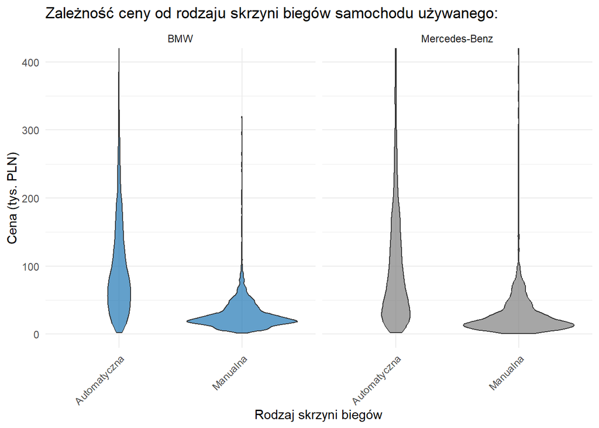

(#tab:unnamed-chunk-25)Cena a skrzynia biegów (używane, Price ≤ 400 000)

| Marka | Skrzynia biegów | Liczba | Średnia | Q1 | Mediana | Q3 |
| --- | --- | --- | --- | --- | --- | --- |
| BMW | Automatic | 9 455 | 97 287 | 46 900 | 78 900 | 131 900 |
| BMW | Manual | 5 435 | 29 276 | 16 500 | 23 400 | 36 900 |
| Mercedes-Benz | Automatic | 7 753 | 98 214 | 34 900 | 73 900 | 139 900 |
| Mercedes-Benz | Manual | 2 884 | 30 667 | 11 900 | 19 900 | 38 500 |

### 3.2.5 Hipoteza H5 (`Pierwszy właściciel a cena`)

Weryfikacja: porównanie `Price` dla zmiennej `First_owner` (tak vs nie) z wykorzystaniem wykresów oraz testów różnic średnich.

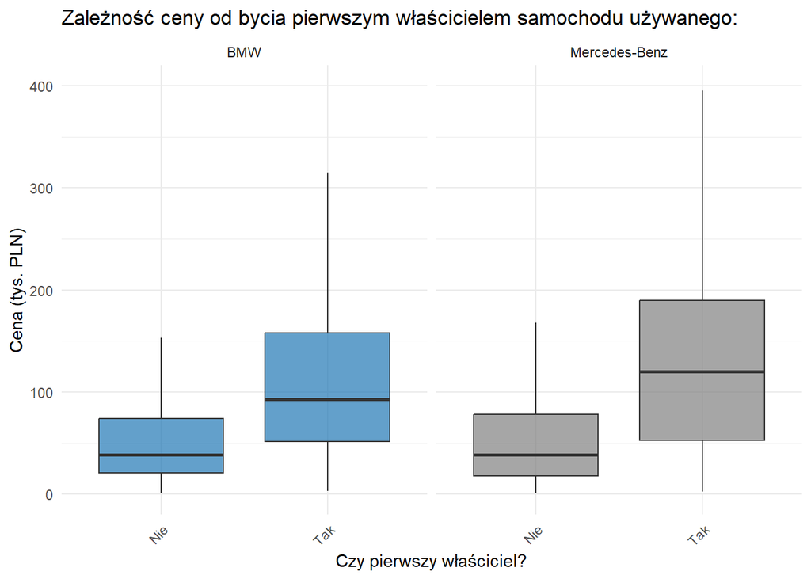

(#tab:unnamed-chunk-27)Cena samochodu w zależności od bycia pierwszym właścicielem (używane, Price ≤ 400 000)

| Marka | Pierwszy właściciel | Liczba | Średnia | Q1 | Mediana | Q3 |
| --- | --- | --- | --- | --- | --- | --- |
| BMW | Nie | 10 515 | 57 557 | 20 900 | 38 900 | 72 900 |
| BMW | Tak | 4 438 | 107 512 | 49 900 | 89 900 | 149 900 |
| Mercedes-Benz | Nie | 7 390 | 59 565 | 17 900 | 38 275 | 77 000 |
| Mercedes-Benz | Tak | 3 281 | 125 676 | 49 900 | 114 900 | 176 000 |

### 3.2.6 Hipoteza H6 (`Napęd a cena`)

Weryfikacja: porównanie rozkładów ceny pomiędzy kategoriami zmiennej `Drive` (np. FWD, RWD, 4x4) z uwzględnieniem innych cech w modelu (m.in. `Power_HP`, `Production_year`)

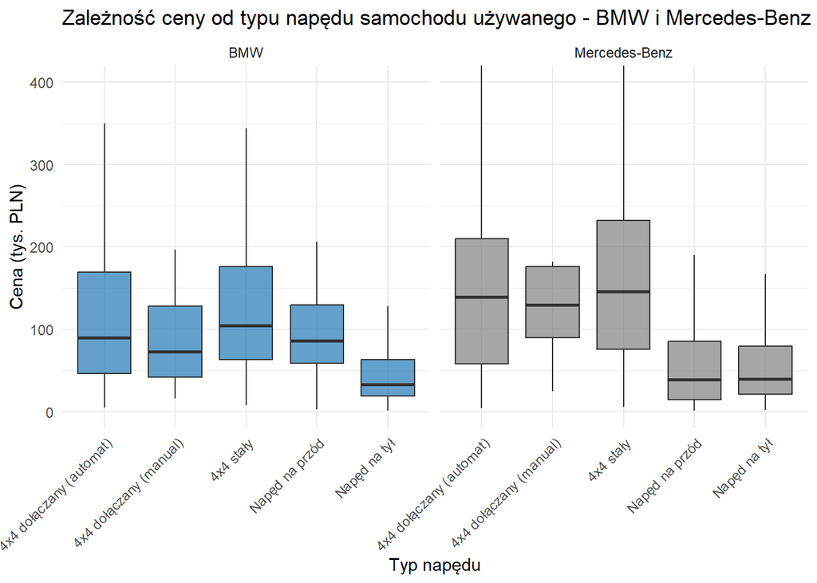

(#tab:unnamed-chunk-29)Cena samochodu w zależności od typu napędu (używane, Price ≤ 400 000)

| Marka | Typ napędu | Liczba | Średnia | Q1 | Mediana | Q3 |
| --- | --- | --- | --- | --- | --- | --- |
| BMW | 4x4 dołączany (automat) | 2 157 | 110 739 | 45 700 | 86 500 | 159 900 |
| BMW | 4x4 dołączany (manual) | 8 | 80 640 | 37 650 | 71 350 | 103 155 |
| BMW | 4x4 stały | 2 758 | 119 767 | 61 900 | 99 500 | 165 289 |
| BMW | Napęd na przód | 572 | 91 914 | 58 868 | 85 700 | 129 900 |
| BMW | Napęd na tył | 8 473 | 48 448 | 19 000 | 32 900 | 62 900 |
| Mercedes-Benz | 4x4 dołączany (automat) | 571 | 142 613 | 54 950 | 131 500 | 199 000 |
| Mercedes-Benz | 4x4 dołączany (manual) | 15 | 120 774 | 85 000 | 129 900 | 174 950 |
| Mercedes-Benz | 4x4 stały | 2 027 | 149 111 | 69 900 | 135 792 | 202 864 |
| Mercedes-Benz | Napęd na przód | 1 917 | 56 048 | 14 500 | 38 745 | 85 000 |
| Mercedes-Benz | Napęd na tył | 5 109 | 59 822 | 20 900 | 39 900 | 77 900 |

Jednocześnie `rozkłady dla napędów na jedną oś nie są identyczne między markami`: w BMW „napęd na przód” jest cenowo zbliżony do 4x4 dołączanego (automat) i wyraźnie wyższy niż „napęd na tył”. W Mercedes-Benz sytuacja jest bardziej jednoznaczna: napęd na przód i na tył mają podobne poziomy cen, natomiast 4x4 (stały i dołączany) tworzy wyraźnie droższy segment, co wzmacnia ogólny wniosek o przewadze cenowej 4x4.

### 3.2.7 Hipoteza H7 (`Moc silnika a cena`)

Weryfikacja: model regresji z ceną `Price` jako zmienną zależną i `Power_HP`, `Mileage_km`, `Production_year` jako głównymi zmiennymi objaśniającymi.

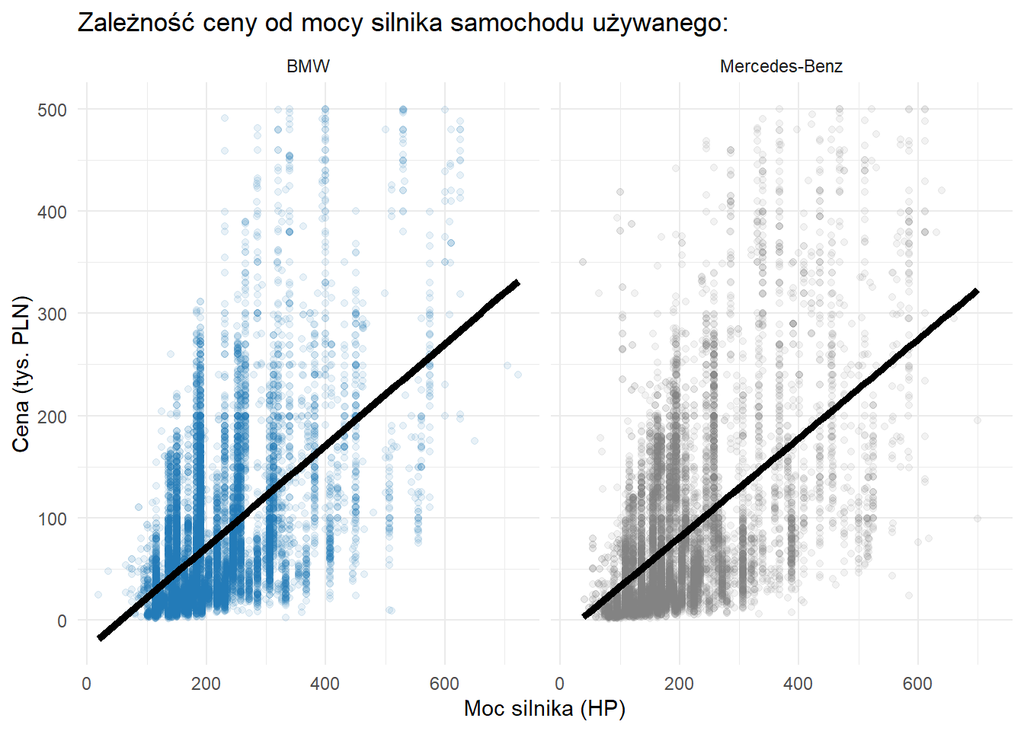

(#tab:unnamed-chunk-31)Cena a moc silnika samochodu używanego (używane, Price ≤ 500 000) – korelacja r

| Marka | Liczba | Średnia | Q1 | Mediana | Q3 | Wsp korelacji |
| --- | --- | --- | --- | --- | --- | --- |
| BMW | 15 068 | 75 308 | 24 470 | 51 000 | 98 000 | 0.55 |
| Mercedes-Benz | 10 796 | 84 160 | 22 000 | 50 999 | 119 000 | 0.55 |

Dane na wykresie i w tabeli wspierają Hipotezę 7: `mocniejsze samochody używane są przeciętnie droższe`, a zależność ma `zbliżoną siłę w BMW i Mercedes-Benz` (r ≈ `0.55`). Jednocześnie widoczny rozrzut punktów wokół linii trendu pokazuje, że `sama moc nie wyjaśnia całej zmienności ceny`, ale `stanowi ważny czynnik` różnicujący oferty.

### 3.2.8 Hipoteza H8 (`Paliwo a cena – BMW vs Mercedes`)

Weryfikacja: boxplot `Price` ~ `Fuel_type` * `Vehicle_brand`, regresja z kontrolą Mileage_km + Production_year.

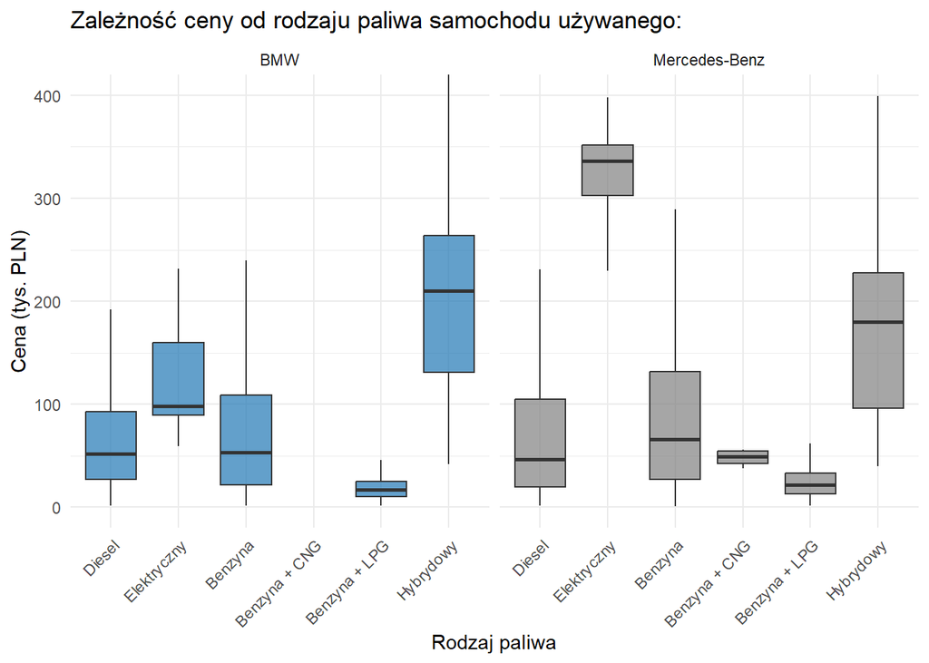

(#tab:unnamed-chunk-33)Cena samochodu w zależności od rodzaju paliwa (używane, Price ≤ 400 000)

| Marka | Rodzaj paliwa | Liczba | Średnia | Q1 | Mediana | Q3 |
| --- | --- | --- | --- | --- | --- | --- |
| BMW | Benzyna | 5 181 | 73 639 | 20 900 | 50 900 | 100 860 |
| BMW | Benzyna + LPG | 451 | 19 104 | 10 000 | 16 900 | 24 950 |
| BMW | Diesel | 8 979 | 71 139 | 26 500 | 50 999 | 90 000 |
| BMW | Elektryczny | 182 | 121 928 | 89 572 | 98 088 | 159 900 |
| BMW | Hybrydowy | 160 | 195 431 | 124 975 | 197 900 | 248 175 |
| Mercedes-Benz | Benzyna | 4 949 | 87 454 | 25 900 | 62 000 | 123 500 |
| Mercedes-Benz | Benzyna + CNG | 4 | 48 025 | 42 425 | 49 250 | 54 850 |
| Mercedes-Benz | Benzyna + LPG | 362 | 26 681 | 12 900 | 22 000 | 32 900 |
| Mercedes-Benz | Diesel | 5 263 | 73 900 | 19 900 | 45 900 | 99 900 |
| Mercedes-Benz | Elektryczny | 32 | 316 318 | 302 375 | 336 450 | 351 644 |
| Mercedes-Benz | Hybrydowy | 61 | 177 251 | 88 800 | 174 900 | 219 800 |

W autach `używanych widać wyraźne różnice cen między rodzajami paliwa` i są one `podobnie uporządkowane w BMW oraz Mercedes-Benz`. Najwyżej wyceniane są napędy alternatywne: w BMW najwyższą medianę mają hybrydy (ok. 197900 PLN) oraz auta elektryczne (ok. 97900 PLN), a w Mercedes-Benz elektryki są zdecydowanie najdroższe (mediana ok. 336450 PLN) i wyraźnie odstają od pozostałych typów.

`W „klasycznych” paliwach Mercedes-Benz jest przeciętnie droższy od BMW`: mediana dla benzyny to ok. 62000 PLN w Mercedesie vs 50000 PLN w BMW, a dla diesla ok. 45900 PLN vs 50900 PLN (tu BMW wypada nieco wyżej medianą, ale Mercedes ma szerszą górę rozkładu w benzynie). `W obu markach instalacje gazowe (Benzyna + LPG) są najtańszą kategorią` (BMW mediana ok. 16900 PLN, Mercedes ok. 22000 PLN), co tworzy wyraźny kontrast względem hybryd i elektryków.

Dodatkowo widać, że `kategorie alternatywne mają mniejsze liczebności` (np. elektryki i hybrydy), ale jednocześnie bardzo wysokie kwartyle, co przekłada się na „drogi” profil tych ofert w całym środkowym zakresie rozkładu (Q1–Q3). W efekcie `paliwo jest jedną z cech, która najsilniej segmentuje ceny`: od najtańszych aut LPG przez benzynę/diesla po wyraźnie droższe hybrydy i elektryki, szczególnie w Mercedes-Benz.

### 3.2.9 Hipoteza H9 (`Kolor a cena – premium psychologia`)

Weryfikacja: boxplot `Price` ~ `Colour` * `Vehicle_brand`, ANOVA z TukeyHSD post-hoc.

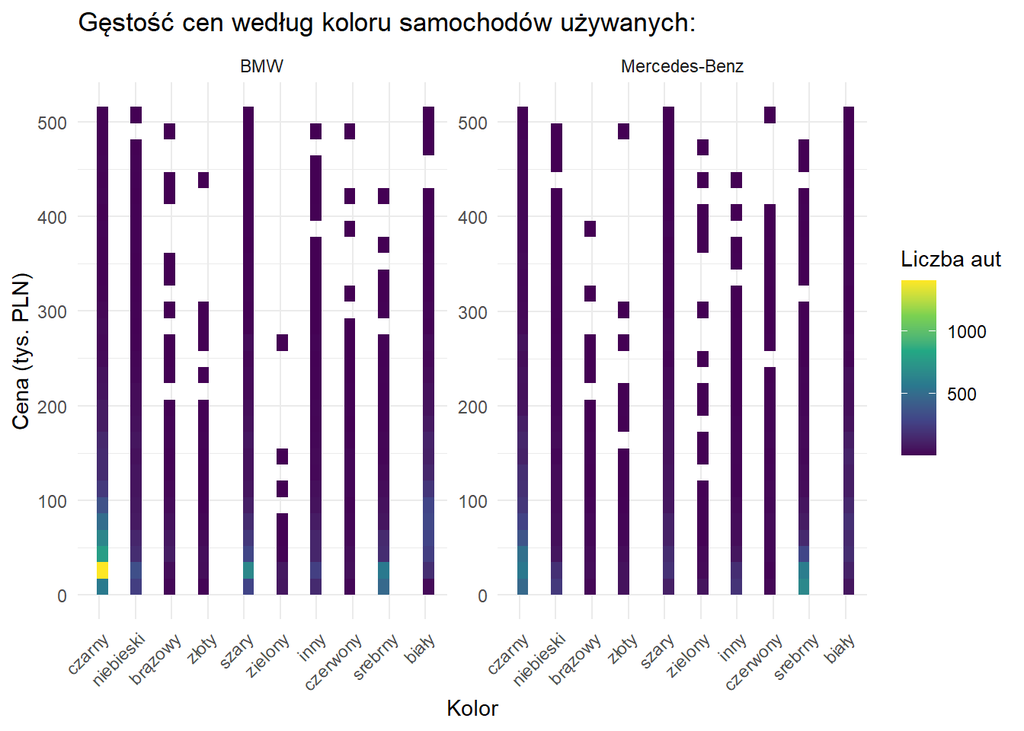

(#tab:unnamed-chunk-35)Cena samochodów używanych według koloru (10 najczęstszych, Price ≤ 500 000)

| Marka | Kolor | Liczba | Średnia | Q1 | Mediana | Q3 |
| --- | --- | --- | --- | --- | --- | --- |
| BMW | biały | 2 219 | 105 699 | 57 900 | 89 900 | 135 900 |
| BMW | brązowy | 376 | 78 656 | 41 900 | 59 800 | 94 625 |
| BMW | czarny | 5 458 | 73 601 | 24 999 | 49 900 | 93 000 |
| BMW | czerwony | 222 | 86 895 | 33 150 | 62 700 | 129 675 |
| BMW | inny | 997 | 66 498 | 22 500 | 45 900 | 82 000 |
| BMW | niebieski | 1 486 | 82 554 | 21 900 | 49 900 | 124 800 |
| BMW | srebrny | 1 616 | 41 201 | 15 800 | 24 650 | 49 900 |
| BMW | szary | 2 212 | 75 187 | 22 900 | 44 900 | 90 000 |
| BMW | zielony | 165 | 27 067 | 10 900 | 18 900 | 26 500 |
| BMW | złoty | 167 | 74 767 | 30 256 | 49 900 | 79 300 |
| Mercedes-Benz | biały | 1 510 | 117 272 | 55 500 | 96 950 | 154 980 |
| Mercedes-Benz | brązowy | 166 | 75 220 | 27 475 | 53 350 | 94 775 |
| Mercedes-Benz | czarny | 3 582 | 95 641 | 28 900 | 60 900 | 129 900 |
| Mercedes-Benz | czerwony | 210 | 119 940 | 58 175 | 98 500 | 169 250 |
| Mercedes-Benz | inny | 613 | 54 697 | 14 900 | 25 900 | 64 900 |
| Mercedes-Benz | niebieski | 785 | 72 547 | 15 999 | 32 900 | 109 900 |
| Mercedes-Benz | srebrny | 2 044 | 45 592 | 14 900 | 25 900 | 49 900 |
| Mercedes-Benz | szary | 1 238 | 108 822 | 35 900 | 76 750 | 158 750 |
| Mercedes-Benz | zielony | 145 | 55 445 | 12 900 | 24 000 | 55 900 |
| Mercedes-Benz | złoty | 190 | 48 409 | 16 900 | 29 850 | 54 350 |

W analizie 10 najczęstszych kolorów wśród aut używanych widać, że `różnice cen między kolorami istnieją`, ale ich kierunek nie jest jednolity „premium vs nie-premium” — bardziej `przypominają efekt tego, jakie modele i roczniki dominują w danym kolorze`. `W obu markach wyraźnie wyżej wypadają kolory takie jak biały i czerwony`: w BMW mediana dla białych aut to 89900 PLN, a dla czerwonych 62700 PLN, natomiast w Mercedes-Benz białe mają medianę 96000 PLN, a czerwone 99000 PLN.

Kolory „popularne” (`czarny, szary`) zwykle plasują się `w środku rozkładu`: w BMW czarny ma medianę 49900 PLN, a szary 44900 PLN, a w Mercedes-Benz czarny 60950 PLN i szary 76900 PLN. Jednocześnie `w obu markach srebrny oraz „inne” kolory mają relatywnie niższe mediany` (BMW srebrny 24800 PLN; Mercedes srebrny 25900 PLN), co sugeruje, że w tych barwach częściej występują tańsze oferty.

Warto też zwrócić uwagę na to, że `rozkłady cen dla części kolorów mają szeroką górę` (wysokie Q3), co widać szczególnie dla białego i czerwonego w Mercedesie (Q3 odpowiednio ok. 154979 i 169900 PLN) oraz dla białego w BMW (Q3 ok. 135900 PLN). Całościowo `kolor może różnicować ceny`, ale `nie jest to „prosty” wzorzec` — w tej próbce najwyżej wyceniane są wybrane barwy (zwłaszcza biały i czerwony), podczas gdy srebrny i część mniej typowych kolorów częściej pojawiają się w niższych segmentach cenowych.

### 3.2.10 Hipoteza H10 (`Trwałość marki – cena/km`)

Weryfikacja: cena_per_km <- `Price` / `Mileage_km`, boxplot po grupach `Production_year` + `Brand`, t-test.

[interactive chart not shown]

(#tab:unnamed-chunk-37)Cena za kilometr samochodu używanego w zależności od grupy roku produkcji

| Marka | Grupa roku produkcji | Liczba | Średnia | Q1 | Mediana | Q3 |
| --- | --- | --- | --- | --- | --- | --- |
| BMW | 2001-2010 | 5 847 | 0.55 | 0.07 | 0.10 | 0.16 |
| BMW | Do 2000 | 749 | 273.66 | 0.03 | 0.05 | 0.12 |
| BMW | Po 2010 | 8 554 | 244.27 | 0.35 | 0.87 | 2.89 |
| Mercedes-Benz | 2001-2010 | 4 332 | 0.22 | 0.06 | 0.11 | 0.19 |
| Mercedes-Benz | Do 2000 | 1 332 | 26.43 | 0.04 | 0.11 | 0.32 |
| Mercedes-Benz | Po 2010 | 5 264 | 519.50 | 0.52 | 1.56 | 5.61 |

`Wyniki dla „ceny za kilometr”` pokazują `bardzo wyraźny podział według rocznika`: w obu markach najnowsze auta (Po 2010) mają zdecydowanie wyższą medianę ceny/km niż starsze grupy, co widać też na boxplotach jako przesunięcie rozkładu w górę. Dla BMW mediana rośnie z ok. 0.05–0.10 PLN/km w grupach „Do 2000” i „2001–2010” do ok. 0.87 PLN/km po 2010, a dla Mercedes-Benz z ok. 0.11 PLN/km do ok. 1.55 PLN/km.

Porównując marki w tej samej grupie rocznika, Mercedes-Benz jest droższy „na kilometr” w najnowszej grupie: po 2010 mediana to ok. 1.55 PLN/km wobec ok. 0.87 PLN/km w BMW, a także wyższy jest cały środek rozkładu (Q1–Q3). Dla roczników 2001–2010 mediany są bardzo zbliżone (ok. 0.10–0.11 PLN/km), co sugeruje, że różnice między markami najmocniej ujawniają się w segmencie nowszych aut.

`Widać też silną prawostronną skośność „ceny/km”` (szczególnie w grupach „Do 2000” i „Po 2010”), gdzie mediany są relatywnie niskie, ale średnie są wielokrotnie wyższe, co wynika z pojedynczych przypadków ekstremalnie wysokiej ceny/km (np. bardzo mały przebieg przy wysokiej cenie). Dlatego w tej hipotezie najbardziej miarodajne do porównań są `mediana i kwartyle`, które `stabilnie pokazują wzrost ceny/km wraz z nowszym rokiem produkcji` oraz `przewagę Mercedesa w autach po 2010`.

### 3.2.11 Hipoteza H11 (`Cena a moc i lokalizacja – BMW vs Mercedes (województwa`) - kilka map

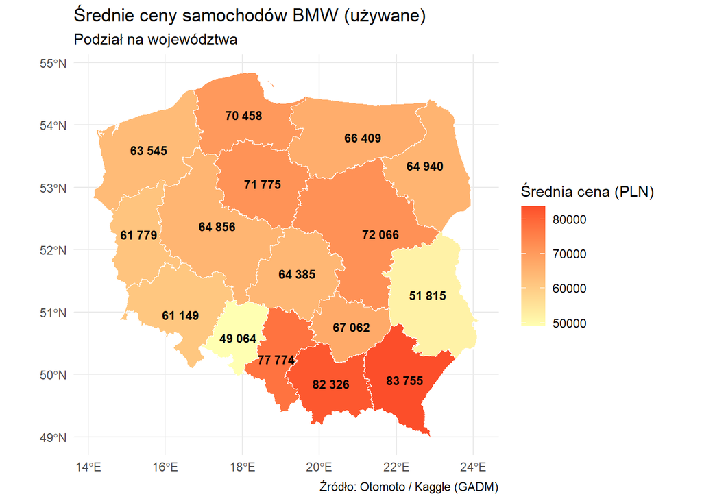

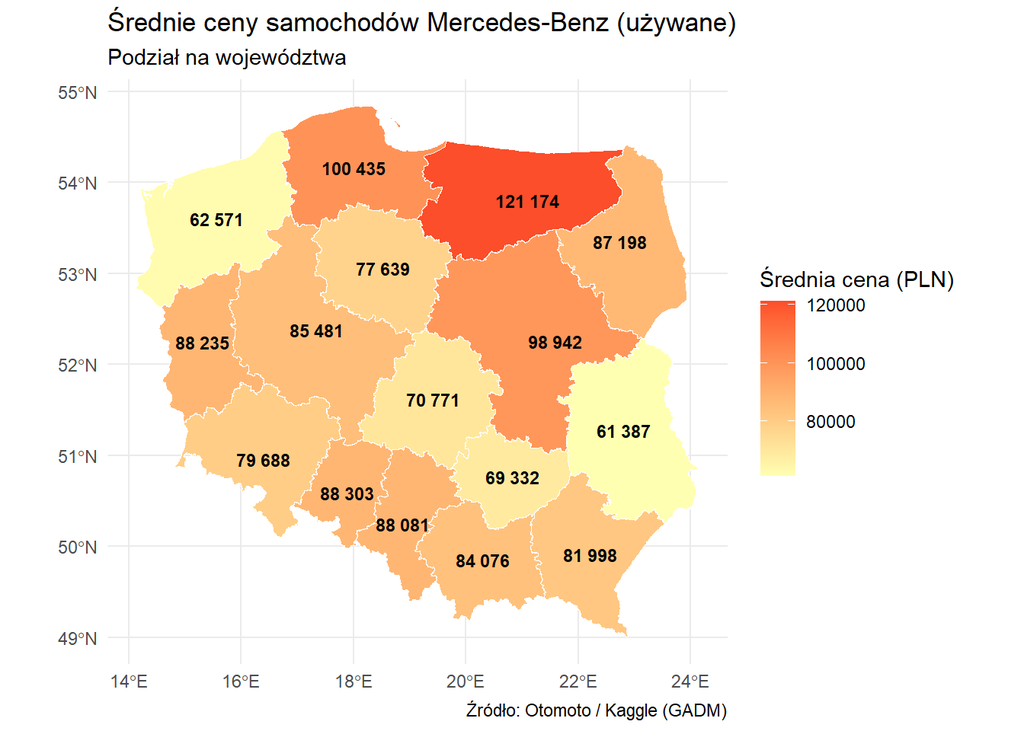

`Średnie ceny aut używanych różnią się między województwami`, a w wielu regionach `Mercedes-Benz osiąga wyższe wartości niż BMW` (np. dolnośląskie: ok. 80 tys. PLN vs ok. 61 tys. PLN). Na mapach widać więc, że `poziom cen nie jest przestrzennie jednolity i zależy od regionu`, co sugeruje zróżnicowanie „profilu” ofert w skali kraju.

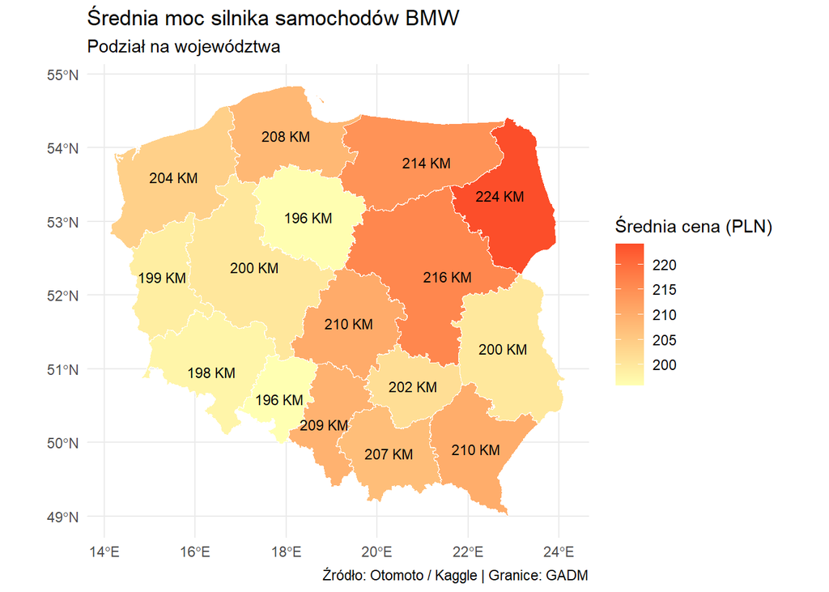

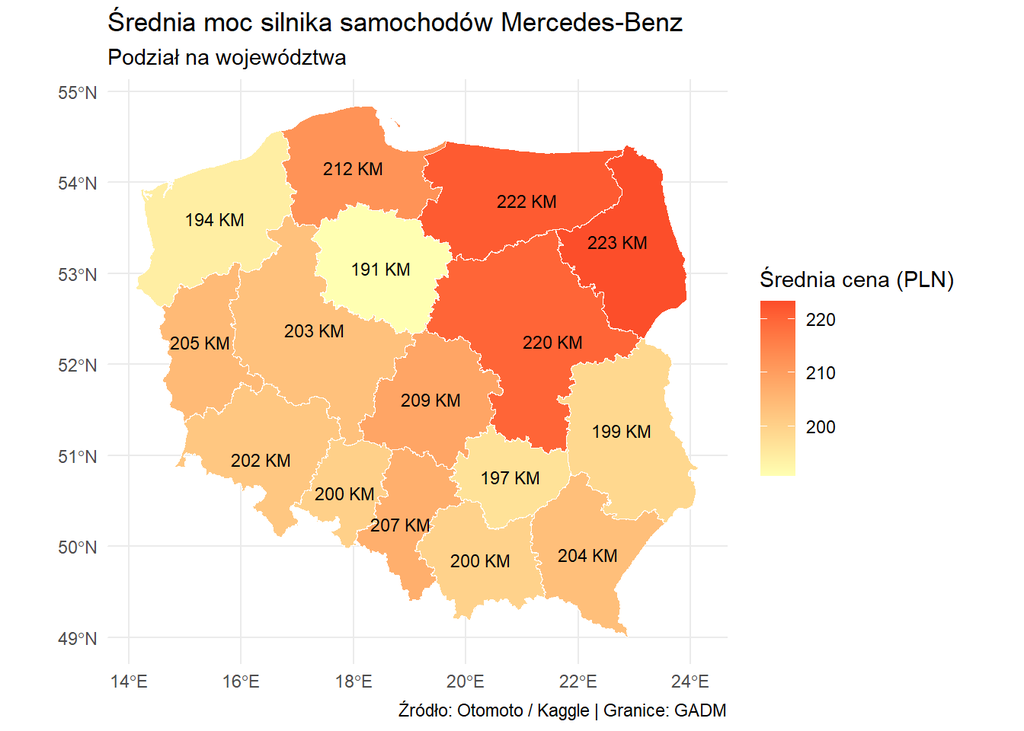

Mapy średniej mocy pokazują podobny regionalny wzorzec: `województwa z wyższymi średnimi cenami często mają też wyższą przeciętną moc silnika` (np. w dolnośląskim średnia moc jest wyższa dla Mercedes-Benz niż dla BMW: ok. 202 KM vs ok. 198 KM). Oznacza to, że `w części regionów struktura ogłoszeń przesuwa się w stronę mocniejszych wersji`, co naturalnie podnosi ogólny poziom ofert.

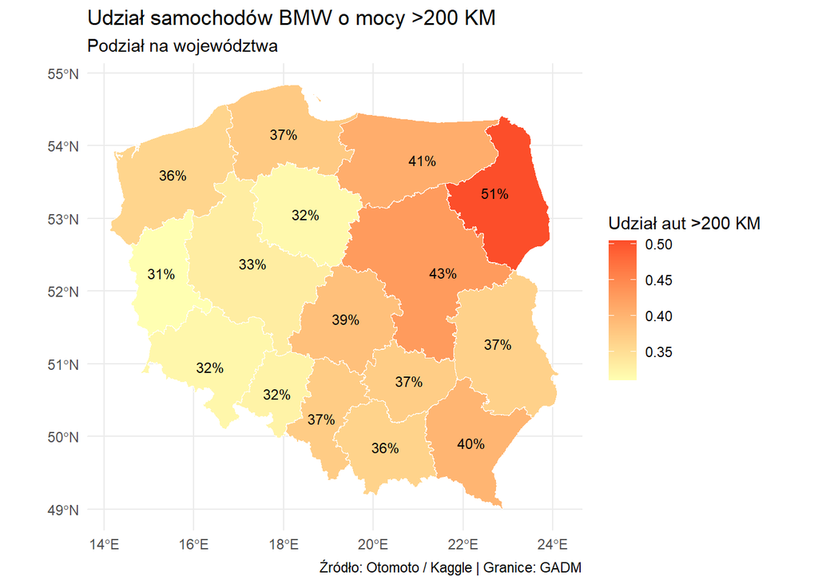

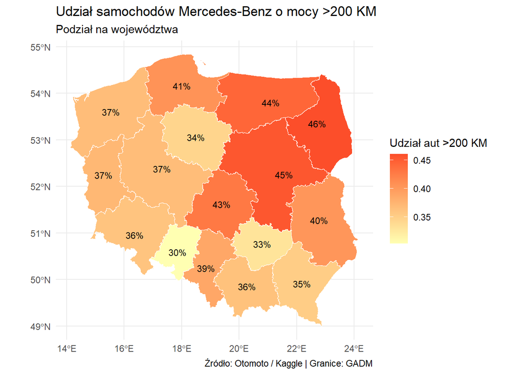

`Udział aut o mocy powyżej 200 KM` domyka ten obraz: `różnice między województwami są widoczne i spójne kierunkowo dla obu marek`. Najwyższe udziały występują w podlaskim (BMW ok. 50%, Mercedes-Benz ok. 46%), a najniższe odpowiednio w lubuskim (BMW ok. 31%) i opolskim (Mercedes-Benz ok. 30%), co pokazuje, że „mocny” segment rynku ma wyraźną koncentrację regionalną.

# 4. Analiza opisowa

## 4.1 Wykres korelacji

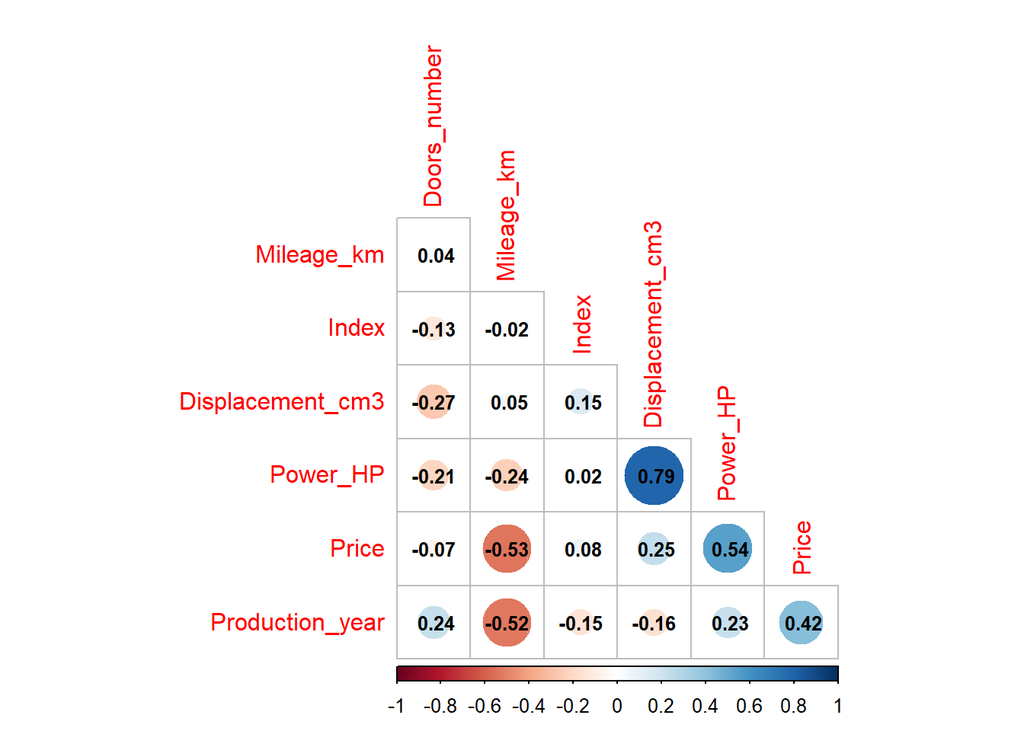

# 5. Wnioskowanie statystyczne

## 5.1 Test ANCOVA

```
##                    Df    Sum Sq   Mean Sq F value Pr(>F)
## Vehicle_brand       1 1.174e+12 1.174e+12   204.7 <2e-16 ***
## Mileage_km          1 8.324e+13 8.324e+13 14516.0 <2e-16 ***
## Production_year     1 9.293e+12 9.293e+12  1620.7 <2e-16 ***
## Residuals       26073 1.495e+14 5.734e+09
## ---
## Signif. codes:  0 '***' 0.001 '**' 0.01 '*' 0.05 '.' 0.1 ' ' 1
```

(#tab:unnamed-chunk-42)Tabela wyników ANCOVA dla ceny w zależności od marki, wielkości przebiegu i roku produkcji

| Źródło | Df | Sum Sq | Mean Sq | F value | Pr(>F) |
| --- | --- | --- | --- | --- | --- |
| Vehicle_brand | 1 | 1.173934e+12 | 1.173934e+12 | 204.7296 | 0 |
| Mileage_km | 1 | 8.323554e+13 | 8.323554e+13 | 14515.9567 | 0 |
| Production_year | 1 | 9.292950e+12 | 9.292950e+12 | 1620.6546 | 0 |
| Residuals | 26073 | 1.495045e+14 | 5.734072e+09 | NA | NA |

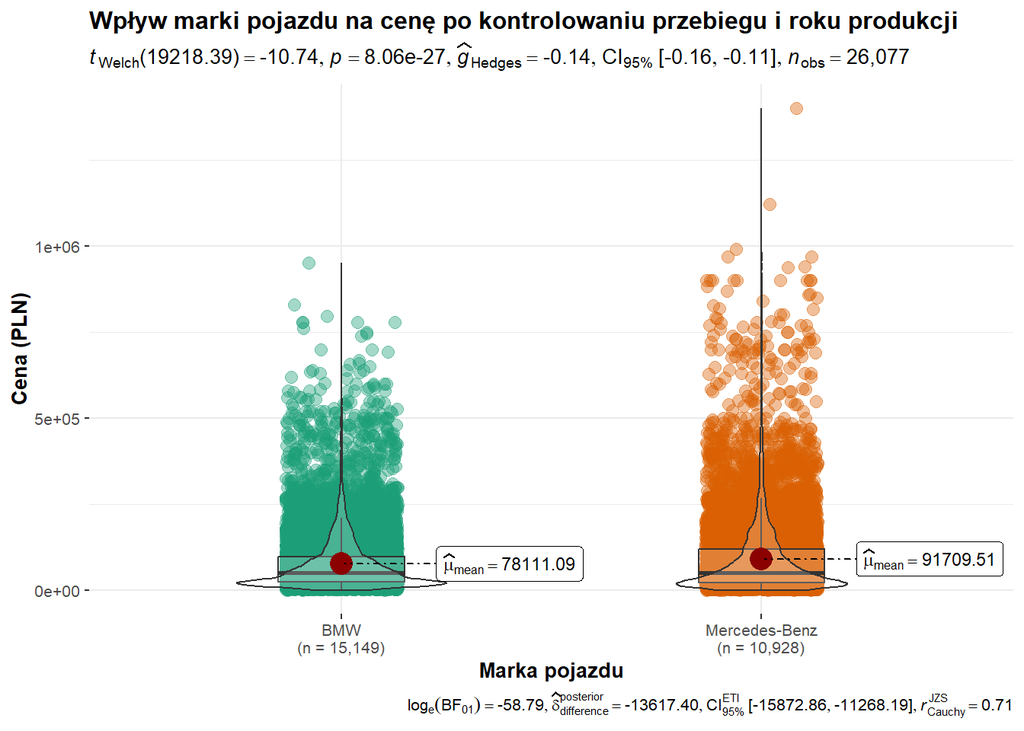

Wyniki ANCOVA dla hipotezy H1 pokazują, że marka pojazdu (`Vehicle_brand`) ma istotny wpływ na cenę (`Price`) po kontrolowaniu przebiegu (`Mileage_km`) i roku produkcji (`Production_year`). Wartość p dla Vehicle_brand jest mniejsza niż 0.05, co pozwala odrzucić hipotezę zerową o braku różnic cen między markami po uwzględnieniu tych czynników kontrolnych. Oznacza to, że `nawet po uwzględnieniu wpływu przebiegu i roku produkcji, marka samochodu pozostaje istotnym czynnikiem różnicującym ceny` samochodów używanych.

## 5.2 ANOVA Price ~ Fuel_type + Transmission

```
##                           Df    Sum Sq   Mean Sq F value Pr(>F)
## Fuel_type                  5 1.030e+13 2.059e+12   268.7 <2e-16 ***
## Transmission               1 3.163e+13 3.163e+13  4126.5 <2e-16 ***
## Fuel_type:Transmission     2 1.754e+12 8.771e+11   114.4 <2e-16 ***
## Residuals              25971 1.991e+14 7.665e+09
## ---
## Signif. codes:  0 '***' 0.001 '**' 0.01 '*' 0.05 '.' 0.1 ' ' 1
```

[interactive chart not shown]

(#tab:unnamed-chunk-43)Mediany cen samochodów używanych w zależności od typu paliwa i skrzyni biegów

| Typ paliwa | Skrzynia biegów | Mediana | Q1 | Q3 | Liczba obserwacji |
| --- | --- | --- | --- | --- | --- |
| Diesel | Automatic | 70355 | 39900.00 | 132000 | 9646 |
| Diesel | Manual | 24990 | 16700.00 | 41600 | 4663 |
| Electric | Automatic | 119900 | 90224.25 | 186556 | 214 |
| Gasoline | Automatic | 89900 | 48900.00 | 151000 | 7114 |
| Gasoline | Manual | 19970 | 13900.00 | 32999 | 3292 |
| Gasoline + CNG | Automatic | 49250 | 42425.00 | 54850 | 4 |
| Gasoline + LPG | Automatic | 24900 | 16900.00 | 35900 | 433 |
| Gasoline + LPG | Manual | 13500 | 8675.00 | 20900 | 376 |
| Hybrid | Automatic | 199900 | 128475.00 | 252851 | 238 |

Na podstawie wyników analizy ANOVA można stwierdzić, że zarówno typ paliwa (`Fuel_type`), jak i skrzynia biegów (`Transmission`) mają `istotny wpływ` na cenę samochodów używanych (p < 0.05). Ponadto, `interakcja między tymi dwoma czynnikami` również jest `istotna statystycznie` (p < 0.05). Odrzucamy hipotezy zerowe i przyjmujemy hipotezę alternatywną, co oznacza, że `ceny używanych samochodów różnią się istotnie w zależności od typu paliwa i skrzyni biegów`. Boxplot wizualizuje te różnice, pokazując zróżnicowanie cen dla różnych kombinacji typu paliwa i skrzyni biegów. Tabela z medianami cen dodatkowo ilustruje, które kombinacje są związane z wyższymi lub niższymi medianami cen samochodów używanych.

## 5.3 Test ANOVA / Kruskal–Wallis Price ~ Fuel_type

```
##
##  Kruskal-Wallis rank sum test
##
## data:  Price by Fuel_type
## Kruskal-Wallis chi-squared = 1486.8, df = 5, p-value < 2.2e-16
```

[interactive chart not shown]

(#tab:unnamed-chunk-45)Mediany cen samochodów używanych w zależności od typu paliwa

| Typ paliwa | Mediana | Q1 | Q3 | Liczba obserwacji |
| --- | --- | --- | --- | --- |
| Diesel | 49900 | 24900.00 | 95900 | 14363 |
| Electric | 119900 | 90224.25 | 186556 | 214 |
| Gasoline | 58500 | 23500.00 | 120900 | 10445 |
| Gasoline + CNG | 49250 | 42425.00 | 54850 | 4 |
| Gasoline + LPG | 18900 | 11500.00 | 28700 | 813 |
| Hybrid | 199900 | 128475.00 | 252851 | 238 |

Na podstawie testu Kruskala-Wallisa można stwierdzić, że `istnieje istotna różnica w medianach cen samochodów używanych w zależności od typu paliwa` (p < 0.05). Odrzucamy hipotezę zerową i przyjmujemy hipotezę alternatywną, co oznacza, że ceny samochodów różnią się istotnie statystycznie w zależności od rodzaju paliwa. Boxplot wizualizuje te różnice, pokazując zróżnicowanie cen dla różnych typów paliwa. Tabela z medianami cen dodatkowo ilustruje, które typy paliwa są związane z wyższymi lub niższymi medianami cen samochodów używanych.

# 6. Podsumowanie

## 6.1 Cel Badawczy

Projekt stanowi kompleksową analizę porównawczą cen i wartości samochodów marek BMW i Mercedes-Benz na polskim rynku wtórnym. Badanie opiera się na zbiorze danych z platformy Kaggle zawierającym ogłoszenia sprzedaży używanych samochodów w Polsce. Autorzy (Paweł Cyrocki, Damian Skinder, Patryk Siuda) zastosowali metodykę opracowaną w języku R z zamiarem identyfikacji kluczowych czynników wpływających na wycenę pojazdów premium.

## 6.2 Kluczowe Hipotezy i Wyniki

(#tab:unnamed-chunk-46)Kluczowe Hipotezy i Wyniki

| Hipoteza | Opis | Rezultat |
| --- | --- | --- |
| H1 | Przebieg a cena | Potwierdzona – ujemna korelacja (r ≈ −0.67 BMW; −0.61 Mercedes) |
| H2 | Rok produkcji a cena | Potwierdzona – nowsze roczniki znacznie droższe |
| H3 | Typ nadwozia a cena | Potwierdzona – SUV-y droższe niż sedany/kompakty |
| H4 | Skrzynia biegów a cena | Potwierdzona – automaty o 55–54 tys. PLN droższe |
| H5 | Pierwszy właściciel a cena | Potwierdzona – auta od 1. właściciela zdecydowanie droższe |
| H6 | Typ napędu a cena | Potwierdzona – napęd 4×4 najwyżej wyceniany |
| H7 | Moc silnika a cena | Potwierdzona – moc istotnie koreluje z ceną (r ≈ 0.55) |
| H8 | Typ paliwa a cena | Potwierdzona – elektryki/hybrydy droższe (Mercedes szczególnie) |
| H9 | Kolor a cena | Częściowo – biały i czerwony wyżej, ale nie ‘czysty’ efekt premium |
| H10 | Cena/km a rok produkcji | Potwierdzona – Mercedes ma wyższy stosunek ceny/km w nowych autach |
| H11 | Cena, moc i lokalizacja | Potwierdzona – zróżnicowanie regionalne (województwa) |

## 6.3 Główne Ustalenia

### 6.3.2 Czynniki Cenowe

Najsilniej ceny różnicują:

Rok produkcji i przebieg (negatywna korelacja z przebiegiem)

Typ paliwa (elektryki/hybrydy premiowane, szczególnie u Mercedes)

Typ napędu (4×4 najdroższy)

Historia właściciela (pierwszy właściciel daje znaczną premię)

### 6.3.4 Wnioskowanie Statystyczne

Test ANCOVA potwierdził istotność marki na cenę po kontrolowaniu przebiegu i roku (p < 0.05)

Test Kruskala-Wallisa wykazał, że typ paliwa istotnie wpływa na ceny (p < 0.05)

Interakcja między paliwem a skrzynią biegów również istotna statystycznie

Analiza Przestrzenna Ceny i moc silników wykazują wyraźne zróżnicowanie regionalne. Województwa takie jak podlaskie charakteryzują się wyższym udziałem aut o mocy >200 KM, co wskazuje na heterogeniczność struktury ofert w kraju.

## 6.4 Wkład Projektu

Projekt stanowi praktyczną aplikację technik analitycznych do rzeczywistego problemu rynku wtórnego. Wyniki mogą być użyteczne dla:

Dealerów i sprzedawców (wycena pojazdów)

Nabywców (identyfikacja uczciwej ceny za samochód)

Analityków rynku (trendy w segmencie premium)

Dokument jest napisany w RMarkdown z formatem bookdown, co ułatwia odtwarzalność i interaktywne przeglądanie wyników.